# R para Ciencia de Datos Club de Lectura r4ds Cap 5

2020-01-12 16:22:01 GMT-5

# Transformación de datos

En (Grolemund and Wickham 2019, Cap 5) aprenderás a transformar tus datos con `dplyr`. Por ejemplo podrás:

- Crear algunas variables nuevas o resúmenes
- Cambiar el nombre de las variables
- Reordenar las observaciones

# Gramática para la manipulación de datos rectangulares

## Clase de objeto que se usa

- `tibble::tibble`

## Principales verbos

- `dplyr::filter()`
- `dplyr::arrange()`
- `dplyr::select()`
- `dplyr::mutate()`
- `dplyr::summarize()`

## Verbo principal para agrupaciones

- `dplyr::group_by()`

## Principal operador para encadenar y facilitar la lectura del código

- `%>%` (paquete `magrittr`)

# `tibble`

- Por ahora las tibbles las definiremos como data frames con propiedades adicionales:

```r
class(x = datos::vuelos)
```

```
## [1] "tbl_df"     "tbl"        "data.frame"
```

```r
datos::vuelos
```

```
## # A tibble: 336,776 x 19
##     anio   mes   dia horario_salida salida_programa… atraso_salida
##    <int> <int> <int>          <int>            <int>         <dbl>
##  1  2013     1     1            517              515             2
##  2  2013     1     1            533              529             4
##  3  2013     1     1            542              540             2
##  4  2013     1     1            544              545            -1
##  5  2013     1     1            554              600            -6
##  6  2013     1     1            554              558            -4
##  7  2013     1     1            555              600            -5
##  8  2013     1     1            557              600            -3
##  9  2013     1     1            557              600            -3
## 10  2013     1     1            558              600            -2
## # … with 336,766 more rows, and 13 more variables: horario_llegada <int>,
## #   llegada_programada <int>, atraso_llegada <dbl>, aerolinea <chr>,
## #   vuelo <int>, codigo_cola <chr>, origen <chr>, destino <chr>,
## #   tiempo_vuelo <dbl>, distancia <dbl>, hora <dbl>, minuto <dbl>,
## #   fecha_hora <dttm>
```

- Para más información ver (Grolemund and Wickham 2019, Cap 10) y https://tibble.tidyverse.org/reference/tbl_df-class.html

# `filter`

Aplica para filas: se seleccionan filas

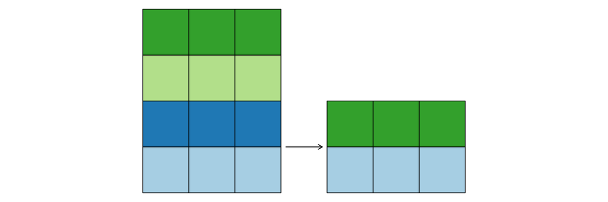

## Plantilla

```r
filter(data = <DATOS>, <EXPRESION QUE RETORNE UN VALOR LOGICO>)
```

- Se requiere conocer el funcionamiento de los operadores lógicos
  - https://stat.ethz.ch/R-manual/R-devel/library/base/html/Logic.html

# `filter`

```r
filter(.data = datos::vuelos, mes == 1, dia == 1)

# Es equivalente a:
## Utilizar "," encadena las condiciones con "&"
filter(.data = datos::vuelos, mes == 1 & dia == 1)
```

```
## # A tibble: 842 x 19
##     anio   mes   dia horario_salida salida_programa… atraso_salida
##    <int> <int> <int>          <int>            <int>         <dbl>
##  1  2013     1     1            517              515             2
##  2  2013     1     1            533              529             4
##  3  2013     1     1            542              540             2
##  4  2013     1     1            544              545            -1
##  5  2013     1     1            554              600            -6
##  6  2013     1     1            554              558            -4
##  7  2013     1     1            555              600            -5
##  8  2013     1     1            557              600            -3
##  9  2013     1     1            557              600            -3
## 10  2013     1     1            558              600            -2
## # … with 832 more rows, and 13 more variables: horario_llegada <int>,
## #   llegada_programada <int>, atraso_llegada <dbl>, aerolinea <chr>,
## #   vuelo <int>, codigo_cola <chr>, origen <chr>, destino <chr>,
## #   tiempo_vuelo <dbl>, distancia <dbl>, hora <dbl>, minuto <dbl>,
## #   fecha_hora <dttm>
```

# `filter`

## Comparaciones

- `>` (mayor que), `>=` (mayor o igual que), `<` (menor que), `<=` (menor o igual que), `!=` (no igual) y `==` (igual).

```r
# Vuelos que tuvieron un retraso de llegada de 1 o más horas
# y volaron a Houston (IAH o HOU)
# y fueron operados por United, American o Delta (UA, AA o DL)
# y partieron en invierno (julio, agosto y septiembre)
# y no salieron tarde
filter(.data = datos::vuelos,
       atraso_llegada >= 60 &
       (destino == "IAH" | destino == "HOU") &
       (aerolinea == "UA" | aerolinea == "AA" | aerolinea == "DL") &
       (mes == 7 | mes == 8 | mes == 9) &
       (atraso_salida <= 0))
```

```
## # A tibble: 4 x 19
##    anio   mes   dia horario_salida salida_programa… atraso_salida
##   <int> <int> <int>          <int>            <int>         <dbl>
## 1  2013     7     1            858              859            -1
## 2  2013     7     9           1721             1721             0
## 3  2013     7    23           1733             1735            -2
## 4  2013     8    14           1625             1625             0
## # … with 13 more variables: horario_llegada <int>, llegada_programada <int>,
## #   atraso_llegada <dbl>, aerolinea <chr>, vuelo <int>, codigo_cola <chr>,
## #   origen <chr>, destino <chr>, tiempo_vuelo <dbl>, distancia <dbl>,
## #   hora <dbl>, minuto <dbl>, fecha_hora <dttm>
```

# `filter`

## Operadores lógicos

- `&` es “y”, `|` es “o” incluyente, `!` es “no”, `xor` es “o” excluyente

[figure not shown]

Conjunto de operadores booleanos (Grolemund and Wickham 2019, Fig 5.1)

# `arrange`

Aplica para filas: se reordenan las filas

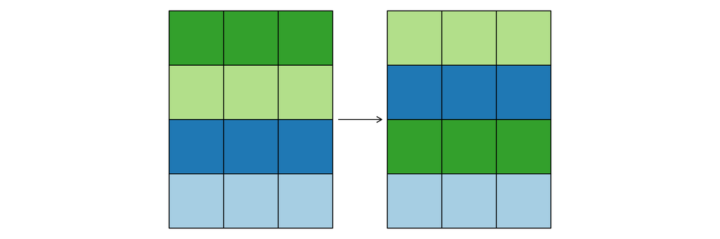

## Plantilla

```r
arrange(data = <DATOS>, <VARIABLES O FUNCIONES APLICADAS A VARIABLES>)
```

# `arrange`

- El orden en que se seleccionan las variables importan donde una variable adicional a la derecha se utiliza para desempatar
- El ordenamiento por defecto se presenta de forma ascendente
  - Si se desea un ordenamiento de forma descendente utilizar `dplyr::desc`
- Los valores `NA` y `NaN` siempre se ordenan al final incluso si se utiliza `dplyr::desc`
- Por defecto se ignora cualquier agrupamiento al utilizar `dplyr::by_group`

```r
tibble(x = c(NA, Inf, 2, 3, NaN, NA, -Inf, TRUE),
       y = c(1, 4, 1, 2, 4, 6, 3, 0)) %>%
  arrange(desc(x), y)
```

```
## # A tibble: 8 x 2
##       x     y
##   <dbl> <dbl>
## 1   Inf     4
## 2     3     2
## 3     2     1
## 4     1     0
## 5  -Inf     3
## 6    NA     1
## 7   NaN     4
## 8    NA     6
```

# `select`

Aplica para columnas: se seleccionan columnas

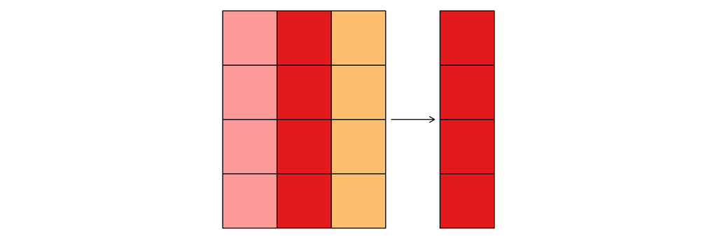

## Plantilla

```r
select(data = <DATOS>, <VARIABLES O EXPRESIONES (SIN COMILLAS)>)
```

# `select`

- Lenguaje para seleccionar variables
  - Operadores: `:`, `!`, `&`, `|`, `c()`
  - Algunas funciones auxiliares: `everything()`, `starts_with()`, `ends_with()`
- Para más detalles ver `tidyselect`: https://tidyselect.r-lib.org/index.html

```r
select(.data = datos::vuelos,
       !(starts_with(match = "a") | ends_with(match = "a")))
```

```
## # A tibble: 336,776 x 6
##      mes vuelo origen destino tiempo_vuelo minuto
##    <int> <int> <chr>  <chr>          <dbl>  <dbl>
##  1     1  1545 EWR    IAH              227     15
##  2     1  1714 LGA    IAH              227     29
##  3     1  1141 JFK    MIA              160     40
##  4     1   725 JFK    BQN              183     45
##  5     1   461 LGA    ATL              116      0
##  6     1  1696 EWR    ORD              150     58
##  7     1   507 EWR    FLL              158      0
##  8     1  5708 LGA    IAD               53      0
##  9     1    79 JFK    MCO              140      0
## 10     1   301 LGA    ORD              138      0
## # … with 336,766 more rows
```

# `mutate`

Aplica para columnas: se crean columnas

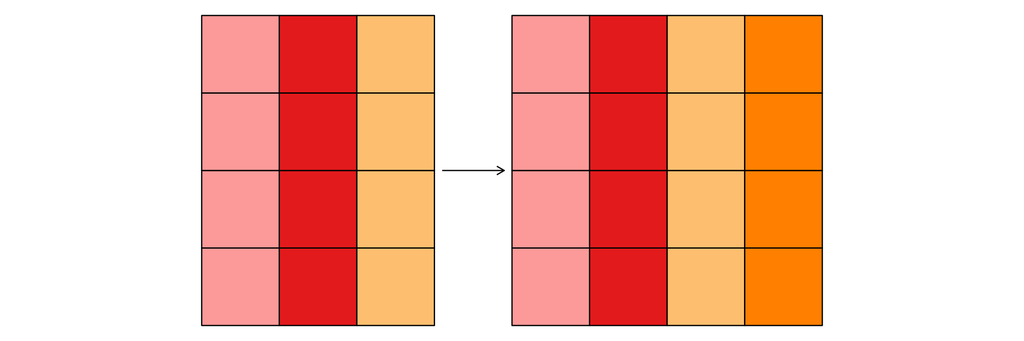

## Plantilla

```r
mutate(data = <DATOS>, <PAR ORDENADO DE NOMBRE Y VALOR>)
```

# `mutate`

- Por defecto agrega valores al final de la tibble
  - Si se quiere cambiar este comportamiento consultar las opciones `.before` y `.after`
- Variables creadas con el mismo nombre de variables existentes reemplazan a estas últimas
- Se pueden utilizar variables creadas en la creación de nueva variables

```r
mutate(.data = datos::vuelos,
       # Convertir distancia de millas a km
       distancia    = distancia * 1.609344,
       # Convertir tiempo de vuelo de minutos a horas
       tiempo_vuelo = tiempo_vuelo / 60,
       # Calcular velocidad media con respecto al suelo (km / hora)
       vel_suelo    = distancia / tiempo_vuelo)[, c("distancia", "tiempo_vuelo", "vel_suelo")]
```

```
## # A tibble: 336,776 x 3
##    distancia tiempo_vuelo vel_suelo
##        <dbl>        <dbl>     <dbl>
##  1     2253.        3.78       596.
##  2     2279.        3.78       602.
##  3     1753.        2.67       657.
##  4     2536.        3.05       832.
##  5     1226.        1.93       634.
##  6     1157.        2.5        463.
##  7     1714.        2.63       651.
##  8      369.        0.883      417.
##  9     1519.        2.33       651.
## 10     1180.        2.3        513.
## # … with 336,766 more rows
```

# `summarize`

Se crean transformaciones estadísticas a partir de una o más columnas

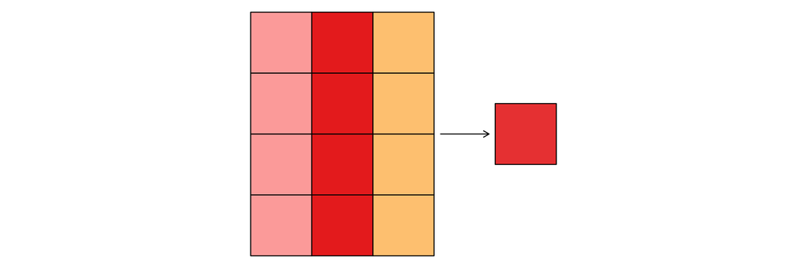

## Plantilla

```r
summarize(data = <DATOS>, <PAR ORDENADO DE NOMBRE Y FUNCION APLICADA A UNA VARIABLE>)
```

# `summarize`

```r
summarize(.data    = datos::vuelos,
          min      = min(atraso_salida, na.rm = TRUE),
          max      = max(atraso_salida, na.rm = TRUE),
          mean     = mean(atraso_salida, na.rm = TRUE),
          median   = median(atraso_salida, na.rm = TRUE),
          # Cálculo de la moda como el primer valor
          # más frecuente (pueden haber varios),
          mode     = modeest::mfv1(atraso_salida, na_rm = TRUE),
          # Cuantiles
          ## En R existen 9 formas de calcular un cuantil dado que no
          ## existe un consenso sobre la definción de cuantil
          q_25     = quantile(atraso_salida, probs = 0.25, na.rm = TRUE, type = 7),
          q_75     = quantile(atraso_salida, probs = 0.75, na.rm = TRUE, type = 7),
          # Estadísticas de dispersión: var, sd, iqr
          var      = var(atraso_salida, na.rm = TRUE),
          sd       = sd(atraso_salida, na.rm = TRUE),
          iqr      = IQR(atraso_salida, na.rm = TRUE, type = 7),
          n        = n(),
          # Valores Na y valores no NA
          na_n     = sum(is.na(atraso_salida)),
          not_na_n = sum(!is.na(atraso_salida)))
```

```
## # A tibble: 1 x 13
##     min   max  mean median  mode  q_25  q_75   var    sd   iqr      n  na_n
##   <dbl> <dbl> <dbl>  <dbl> <dbl> <dbl> <dbl> <dbl> <dbl> <dbl>  <int> <int>
## 1   -43  1301  12.6     -2    -5    -5    11 1617.  40.2    16 336776  8255
## # … with 1 more variable: not_na_n <int>
```

# `group_by`

Agrupa filas en base a valores de una o más columnas

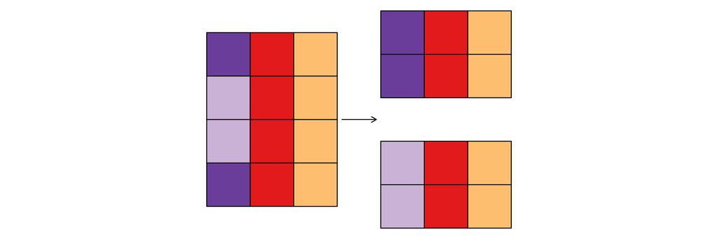

## Plantilla

```r
group_by(data = <DATOS>, <VARIABLES PARA REALIZAR LAS AGRUPACIONES>)
```

# `group_by`

- Si existen valores `NA` o `NaN` cada uno se agrupa en un conjunto distinto
- La tibble que se genera señala las variables que se utilizan para agrupar así como el número de grupos que se conforman
- Si se desea reversar la agrupación utilizar `dplyr::ungroup`

```r
group_by(.data = tibble(x = c(NA, 1, 1, NaN, 2, NA, 2, 3, NaN ,3),
                          y = 1:10),
         x)
```

```
## # A tibble: 10 x 2
## # Groups:   x [5]
##        x     y
##    <dbl> <int>
##  1    NA     1
##  2     1     2
##  3     1     3
##  4   NaN     4
##  5     2     5
##  6    NA     6
##  7     2     7
##  8     3     8
##  9   NaN     9
## 10     3    10
```

# `%>%`

- $f(x = a, y = b)$ es equivalente a:
  - $a \text{ %>% } f(y = b)$
  - $b \text{ %>% } f(x = a, y = \; .)$
    - En el caso del tidyverse $a \text{ %>% } f(y = b)$ es la equivalencia más utilizada dado que el primer argumento de las funciones corresponde a los datos
- Mejora la lectura del código
  - $f(g(h(s(x = a))), y = b)$
  - $\begin{matrix} s(a) & \text{ %>% } & \text{Paso 1} \\ h() & \text{ %>% } & \text{Paso 2} \\ g() & \text{ %>% } & \text{Paso 3} \\ f(y = b) & \text{} & \text{Paso 4} \end{matrix}$

# `%>%`

## Aplicaciones

```r
datos::vuelos %>%
  filter(!is.na(atraso_salida)) %>%
  group_by(mes) %>%
  # Por defecto summarize elimina las agrupaciones
  summarize(mean = mean(atraso_salida), median = median(atraso_salida), n = n())
```

```
## # A tibble: 12 x 4
##      mes  mean median     n
##    <int> <dbl>  <dbl> <int>
##  1     1 10.0      -2 26483
##  2     2 10.8      -2 23690
##  3     3 13.2      -1 27973
##  4     4 13.9      -2 27662
##  5     5 13.0      -1 28233
##  6     6 20.8       0 27234
##  7     7 21.7       0 28485
##  8     8 12.6      -1 28841
##  9     9  6.72     -3 27122
## 10    10  6.24     -3 28653
## 11    11  5.44     -3 27035
## 12    12 16.6       0 27110
```

# `%>%`

## Aplicaciones

```r
tibble(x = c(1, 1, 2, 2, 3, 3, NA, NA),
       y = c(2, 5, 1, 0, 9, 2,  3, 2)) %>%
  group_by(x) %>%
  # .by_group = TRUE: para que no se ignore el agrupamiento
  arrange(y, .by_group = TRUE)
```

```
## # A tibble: 8 x 2
## # Groups:   x [4]
##       x     y
##   <dbl> <dbl>
## 1     1     2
## 2     1     5
## 3     2     0
## 4     2     1
## 5     3     2
## 6     3     9
## 7    NA     2
## 8    NA     3
```

# Extensiones utilizando la filosofía del tidyverse

- `naniar`: manejo de valores `NA` (http://naniar.njtierney.com/index.html)
- `timetk`: manejo de series de tiempo (https://business-science.github.io/timetk/)

## Aplicaciones `naniar`

```r
naniar::miss_var_which(data = datos::vuelos)
naniar::miss_var_table(data = datos::vuelos)
```

```
## [1] "horario_salida"  "atraso_salida"   "horario_llegada" "atraso_llegada"
## [5] "codigo_cola"     "tiempo_vuelo"
```

```
## # A tibble: 5 x 3
##   n_miss_in_var n_vars pct_vars
##           <int>  <int>    <dbl>
## 1             0     13    68.4
## 2          2512      1     5.26
## 3          8255      2    10.5
## 4          8713      1     5.26
## 5          9430      2    10.5
```

# Extensiones utilizando la filosofía del tidyverse

## Aplicaciones `timetk`

```r
datos::vuelos %>%
  timetk::filter_by_time(.date_var   = fecha_hora,
                         .start_date = "2013-06-01",
                         .end_date   = "2013-12-31") %>%
  timetk::summarize_by_time(.date_var = fecha_hora,
                    .by       = "month",
                    min       = min(atraso_salida, na.rm = TRUE),
                    max       = min(atraso_salida, na.rm = TRUE),
                    median    = median(atraso_salida, na.rm = TRUE),
                    mean      = mean(atraso_salida, na.rm = TRUE))
```

```
## # A tibble: 7 x 5
##   fecha_hora            min   max median  mean
##   <dttm>              <dbl> <dbl>  <dbl> <dbl>
## 1 2013-06-01 00:00:00   -21   -21      0 20.8
## 2 2013-07-01 00:00:00   -22   -22      0 21.7
## 3 2013-08-01 00:00:00   -26   -26     -1 12.6
## 4 2013-09-01 00:00:00   -24   -24     -3  6.72
## 5 2013-10-01 00:00:00   -25   -25     -3  6.24
## 6 2013-11-01 00:00:00   -32   -32     -3  5.44
## 7 2013-12-01 00:00:00   -43   -43      0 16.6
```

# Referencias

Grolemund, Garrett, and Hadley Wickham. 2019. *R Para Ciencia de Datos*. http://es.r4ds.hadley.nz/.